# Bootstrap and Permutation Inference: An Empirical Example

- Show All Code
- Hide All Code
- View Source

Effects of a Training Program on Earnings (NSW)

Author

Mauricio Olivares

Published

July 31, 2026

# 1 Overview

This chapter revisits the empirical exercise from LaLonde (1986), whose goal is to evaluate a landmark training program in the United States: the **National Supported Work Demonstration (NSW)**. The NSW was a temporary employment program designed to move disadvantaged workers, lacking basic job skills, into the labor market by providing subsidised work experience and counselling in a sheltered environment. Qualified applicants were assigned to training positions **at random**: the treatment group received the full NSW benefits, while the control group received none.

Our working sample consists of male participants with relatively poor labor market prospects. Because assignment was randomized, this data set is the natural laboratory in which to exercise the three approaches to inference developed in the course — **asymptotic**, **randomization**, and **bootstrap** — and to contrast the **average treatment effect (ATE)** with the **quantile treatment effect (QTE)**.

# 2 Potential Outcomes and the Target Parameters

For individual $i$ with binary treatment $D_i \in \{0,1\}$ and pre-determined covariates $X_i$, define the potential outcomes

$$Y_i(1) = \text{earnings had } i \text{ participated}, \qquad
Y_i(0) = \text{earnings had } i \text{ not participated},$$

with observed earnings $Y_i = D_i Y_i(1) + (1 - D_i) Y_i(0)$.

**ImportantStable Unit Treatment Value Assumption (SUTVA)**

SUTVA requires (i) **no interference** — one unit’s potential outcomes do not depend on the treatment status of any other unit — and (ii) **no hidden variation in treatment** — there is a single, well-defined version of the program. SUTVA typically fails under spillovers (e.g. a trained worker displacing an untrained one from a job) or when the “treatment” bundles heterogeneous interventions.

We consider two target parameters. The **average treatment effect**

$$\text{ATE} \;=\; \mathbb{E}\big[Y_i(1) - Y_i(0)\big],$$

summarizes the program’s effect on the *mean* of earnings. The **quantile treatment effect** at level $\tau \in (0,1)$,

$$\text{QTE}_\tau \;=\; F_1^{-1}(\tau) - F_0^{-1}(\tau),$$

where $F_d$ is the CDF of earnings in experimental arm $d \in \{0,1\}$, describes the effect across the *entire distribution* of earnings. Neither the individual effect $\beta_i = Y_i(1) - Y_i(0)$ nor these population parameters are directly observable, because for each $i$ we see only one of the two potential outcomes.

## 2.1 Identification under Random Assignment

**NoteRandom assignment restores identification**

If $\{(Y_i(1), Y_i(0))\}_{i=1}^n \perp \{D_i\}_{i=1}^n$, and $0<P(D_i=1)<1$ for all $i$, then the target parameters are expressed in terms of observables:

$$\mathbb{E}[Y_i(1) - Y_i(0)] = \mathbb{E}[Y_i \mid D_i = 1] - \mathbb{E}[Y_i \mid D_i = 0],$$

$$F_1^{-1}(\tau) - F_0^{-1}(\tau) = F^{-1}(\tau \mid D_i = 1) - F^{-1}(\tau \mid D_i = 0).$$

The obstacle to identification without exogenous randomization is **selection bias**. We studied two types of selection during the lecture. *Selection on levels* arises when treated and control units differ in their baseline outcome $Y_i(0)$ (e.g. more motivated workers enrol *and* would have earned more anyway). *Selection on gains* arises when units select into treatment on the basis of their idiosyncratic return $Y_i(1) - Y_i(0)$. Random assignment cancels both channels, which is precisely why the NSW design is credible as a devide to uncover causal estimands, like ATEs or QTEs.

# 3 The Data

The experimental sample contains 445 male participants. The outcome is `re78`, real earnings in 1978 (post-treatment), in 1982 US dollars. Pre-treatment earnings (`re74`, `re75`), demographics, and schooling serve as covariates. Rather than the raw `summary()` output — which is hard to read and lists every dummy as a five-number summary — we report a compact **balance table**. Because assignment is randomized, the two arms should look alike on every pre-determined covariate, and Table 1 lets us check this at a glance: continuous variables are shown as the group mean (with the standard deviation in parentheses), and the many binary indicators as simple proportions.

**Build the covariate balance table**

```r
cont_vars  <- c("age", "education", "re74", "re75")
bin_vars   <- c("black", "hispanic", "married", "nodegree", "u74", "u75")
var_labels <- c(age       = "Age (years)",
                education = "Years of schooling",
                re74      = "Real earnings 1974 (US$)",
                re75      = "Real earnings 1975 (US$)",
                black     = "Black",
                hispanic  = "Hispanic",
                married   = "Married",
                nodegree  = "No high-school degree",
                u74       = "Unemployed in 1974",
                u75       = "Unemployed in 1975")

grp <- lalonde.exp$treat
n0  <- sum(grp == 0)
n1  <- sum(grp == 1)

fmt_money <- function(z) formatC(z, format = "f", big.mark = ",", digits = 0)

summarise_var <- function(v) {
  x0 <- lalonde.exp[[v]][grp == 0]
  x1 <- lalonde.exp[[v]][grp == 1]
  if (v %in% bin_vars) {
    data.frame(Variable   = var_labels[[v]],
               Control    = sprintf("%.1f%%", 100 * mean(x0)),
               Treatment  = sprintf("%.1f%%", 100 * mean(x1)),
               Difference = sprintf("%+.1f pp", 100 * (mean(x1) - mean(x0))),
               stringsAsFactors = FALSE)
  } else {
    earn <- v %in% c("re74", "re75")
    ctrl <- if (earn) sprintf("%s (%s)", fmt_money(mean(x0)), fmt_money(sd(x0)))
            else      sprintf("%.2f (%.2f)", mean(x0), sd(x0))
    trt  <- if (earn) sprintf("%s (%s)", fmt_money(mean(x1)), fmt_money(sd(x1)))
            else      sprintf("%.2f (%.2f)", mean(x1), sd(x1))
    dff  <- if (earn) fmt_money(mean(x1) - mean(x0))
            else      sprintf("%.2f", mean(x1) - mean(x0))
    data.frame(Variable = var_labels[[v]], Control = ctrl,
               Treatment = trt, Difference = dff, stringsAsFactors = FALSE)
  }
}

balance_tab <- do.call(rbind, lapply(c(cont_vars, bin_vars), summarise_var))

kbl(balance_tab,
    col.names = c("", sprintf("Control (n = %d)", n0),
                      sprintf("Treatment (n = %d)", n1), "Difference"),
    align = "lccc") |>
  kable_styling(bootstrap_options = c("striped", "hover"), full_width = FALSE) |>
  pack_rows("Continuous  \u2014  mean (SD)", 1, length(cont_vars)) |>
  pack_rows("Binary  \u2014  proportion",
            length(cont_vars) + 1, length(cont_vars) + length(bin_vars))
```

Table 1: Baseline covariate balance across treatment arms. Continuous variables report the group mean with the standard deviation in parentheses; binary indicators report the group proportion. The final column is the treated-minus-control difference (pp = percentage points).

|  | Control (n = 260) | Treatment (n = 185) | Difference |
| --- | --- | --- | --- |
| **Continuous — mean (SD)** |  |  |  |
| Age (years) | 25.05 (7.06) | 25.82 (7.16) | 0.76 |
| Years of schooling | 10.09 (1.61) | 10.35 (2.01) | 0.26 |
| Real earnings 1974 (US$) | 2,107 (5,688) | 2,096 (4,887) | -11 |
| Real earnings 1975 (US$) | 1,267 (3,103) | 1,532 (3,219) | 265 |
| **Binary — proportion** |  |  |  |
| Black | 82.7% | 84.3% | +1.6 pp |
| Hispanic | 10.8% | 5.9% | -4.8 pp |
| Married | 15.4% | 18.9% | +3.5 pp |
| No high-school degree | 83.5% | 70.8% | -12.7 pp |
| Unemployed in 1974 | 75.0% | 70.8% | -4.2 pp |
| Unemployed in 1975 | 68.5% | 60.0% | -8.5 pp |

# 4 Estimating the ATE

Under random assignment, the ATE is identified by the mean difference across experimental groups, and the principle of analogy tells us we can estimate it by the *sample* mean difference. Equivalently, it is the slope in a regression of earnings on a constant and the treatment indicator (why?).

**Estimate the ATE two equivalent ways**

```r
# (i) Sample mean difference
ate_1 <- mean(lalonde.exp$re78[lalonde.exp$treat == 1]) -
         mean(lalonde.exp$re78[lalonde.exp$treat == 0])

# (ii) OLS slope
mod1 <- lm(re78 ~ treat, data = lalonde.exp)

c(mean_difference = ate_1, ols_slope = unname(mod1$coefficients[2]))
```

```
mean_difference       ols_slope
       1794.343        1794.343
```

The two estimates coincide: the estimated ATE is roughly 1794.34 dollars.

# 5 Asymptotic Inference

The four steps of inference are: (1) state the null, here $H_0:\text{ATE}=0$; (2) choose a test statistic; (3) approximate its sampling distribution under $H_0$; (4) apply a rejection rule. We use the studentized statistic

$$T_n \;=\; \frac{\hat\beta - \beta_0}{\widehat{\mathrm{SE}}(\hat\beta)}
\;\overset{H_0}{=}\; \frac{\hat\beta}{\widehat{\mathrm{SE}}(\hat\beta)},$$

which is asymptotically standard normal under $H_0$ because it is already studentized. Note that no explicit $\sqrt{n}$ appears: the standard error $\widehat{\mathrm{SE}}(\hat\beta) = \sqrt{\widehat{\mathrm{Var}}(\hat\beta)/n}$ already carries the scaling.

The same statistic delivers all three equivalent rejection rules — a critical value, a $p$-value, and a confidence interval. The interval *inverts* the test: at level $\alpha$ it collects the null values that $T_n$ would not reject. By symmetry of the normal ($z_{1-\alpha/2} = -z_{\alpha/2}$), this is the familiar asymptotic interval

$$\hat C_n(1-\alpha) = \Big[\,\hat\beta - z_{1-\alpha/2}\,\widehat{\mathrm{SE}}(\hat\beta),\;
\hat\beta + z_{1-\alpha/2}\,\widehat{\mathrm{SE}}(\hat\beta)\,\Big],$$

which is exactly the object computed as `asy_ci` below.

**ImportantA confidence interval is not a probability statement about the estimand**

$\hat C_n$ is random because it is built from data, and the guarantee is $\mathbb{P}[\text{ATE} \in \hat C_n] \ge 1-\alpha$, at least asymptotically. Once the sample is realized there is no randomness left: a given realization $[L, U]$ either contains the ATE or it does not. The level $1-\alpha$ describes the *procedure’s* coverage — “confidence” — not a probability for this particular interval.

**Studentized test statistic as a function of (Y, D)**

```r
t_stat <- function(outcome, treatment) {
  mod         <- lm(outcome ~ 1 + treatment)
  se_beta_hat <- summary(mod)$coefficients[2, 2]   # SE from THIS fit
  tn          <- mod$coefficients[2] / se_beta_hat
  unname(tn)
}
```

**Asymptotic test, p-value, and confidence interval**

```r
Tn_obs <- t_stat(lalonde.exp$re78, lalonde.exp$treat)

# Rejection rule: reject if |T_n| exceeds the normal critical value
reject_asy <- (Tn_obs > qnorm(1 - alpha / 2))

# p-value straight from the regression table
p_value <- summary(mod1)$coefficients[2, 4]

# 95% asymptotic CI: beta_hat +/- z_{1-alpha} * SE
se_beta_hat <- summary(mod1)$coefficients[2, 2]
asy_ci <- mod1$coefficients[2] + c(-1, 1) * qnorm(1 - alpha / 2) * se_beta_hat

cat("T_n           :", round(Tn_obs, 4), "\n")
```

```
T_n           : 2.8353
```

**Asymptotic test, p-value, and confidence interval**

```r
cat("Reject H0     :", reject_asy, "\n")
```

```
Reject H0     : TRUE
```

**Asymptotic test, p-value, and confidence interval**

```r
cat("p-value       :", round(p_value, 4), "\n")
```

```
p-value       : 0.0048
```

**Asymptotic test, p-value, and confidence interval**

```r
cat("95% CI (ATE)  : [", round(asy_ci[1], 2), ",", round(asy_ci[2], 2), "]\n")
```

```
95% CI (ATE)  : [ 553.97 , 3034.71 ]
```

The estimated ATE is significant at the 5% level, and the confidence interval excludes zero: the NSW program raises male earnings by about 1794 dollars per year on average (in 1982 dollars).

# 6 Randomization Inference

**ImportantRandomization Hypothesis**

Let $\mathbf{G}_n$ be a group of transformations acting on the data $W^{(n)}$. The law $P_n$ satisfies the randomization hypothesis if $W^{(n)} \stackrel{d}{=} g\,W^{(n)}$ for all $g \in \mathbf{G}_n$ whenever $P_n \in \Omega_0$. When it holds, the permutation test is **exact in finite samples** for any test statistic.

A subtlety arises here. The null $H_0:\text{ATE}=0$ is a statement about *means*, not about the *joint distribution*, so the randomization hypothesis does **not** hold for it in general: two distributions can share the same mean while differing elsewhere (e.g., different variances), and permuting labels would then change the distribution of the data. Nonetheless, when testing equality of means with a **properly studentized** statistic, we showed during lecture that the permutation test controls size *asymptotically* (Chung and Romano 2013). While the asymptotic statements are only theoretical devices, one could argue that for $n = 445$, the approximation might be adequate. We can inspect this claim empirically too.

**Build the randomization distribution of T_n**

```r
data_subset <- lalonde.exp[, c("re78", "treat")]

# Permute the treatment vector n_perm times ...
sample_ind     <- lapply(1:n_perm, function(x) sample(seq_along(data_subset$treat)))
perm_data_list <- lapply(sample_ind, function(x, db) db[x], data_subset$treat)
perm_data      <- do.call(cbind, perm_data_list)

# ... and append the original assignment as the last column
perm_data <- cbind(perm_data, data_subset$treat)

# Recompute T_n under each (permuted) assignment
t_stat_perm <- apply(perm_data, 2, function(x) t_stat(data_subset[, 1], x))

# Permutation critical value and rejection decision
cn_alpha <- quantile(t_stat_perm, 1 - alpha / 2)
c(perm_cv = unname(cn_alpha), normal_cv = qnorm(1 - alpha / 2))
```

```
  perm_cv normal_cv
 1.943040  1.959964
```

**Build the randomization distribution of T_n**

```r
(Tn_obs > cn_alpha)
```

```
97.5%
 TRUE
```

The permutation critical value settles around the the quantile of the standard normal distribution $z_{0.975}$ as the sample size grows. Indeed, the two tests reach the same conclusion: we reject $H_0:\text{ATE}=0$.

**Plot the randomization distribution**

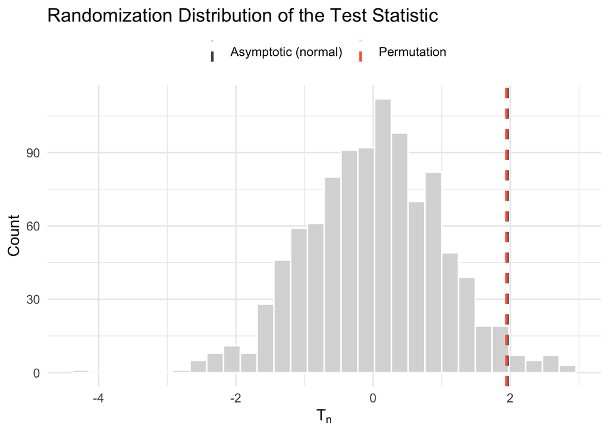

Figure 1: Randomization distribution of $T_n$ over 1000 permutations, with the permutation and asymptotic (normal) critical values.

```r
cv_rand <- data.frame(
  value     = c(qnorm(1 - alpha / 2), cn_alpha),
  Reference = factor(c("Asymptotic (normal)", "Permutation"),
                     levels = c("Asymptotic (normal)", "Permutation"))
)

ggplot(data.frame(t_stat_perm = t_stat_perm), aes(x = t_stat_perm)) +
  geom_histogram(bins = 30, fill = "grey85", color = "white") +
  geom_vline(data = cv_rand, aes(xintercept = value, color = Reference),
             linetype = "dashed", linewidth = 1) +
  scale_color_manual(values = c("Asymptotic (normal)" = "grey30",
                                "Permutation"         = col_control),
                     name = NULL) +
  theme_minimal(base_size = 13) +
  theme(legend.position = "top") +
  labs(title = "Randomization Distribution of the Test Statistic",
       x = expression(T[n]), y = "Count")
```

**TipThe sharp null makes the test *exact**

Consider instead Fisher’s **sharp null** $H_0: Y_i(1) = Y_i(0)$ for all $i$ (almost surely or in distribution). Under an i.i.d. sample this null implies that the vector of outcomes is invariant in distribution to any permutation of the treatment labels, so the randomization hypothesis holds *exactly*. The same construction of the permutation distribution then yields a test that is valid in finite samples, not only asymptotically. Because $\mathbf{G}_n$ has $n!$ elements, we sidestep exact over all permutations by drawing $B \ll n!$ permutations uniformly at random, as above.

# 7 Bootstrap Inference

The empirical bootstrap is the **plug-in** estimator of the sampling distribution: it replaces the unknown law $P$ by the empirical measure $\hat P_n$ and reads off the distribution of $T_n$ under $\hat P_n$. Exact evaluation requires $n^n$ resamples, so in practice we use the **Monte Carlo approximation**. That is, we draw $B$ resamples with replacement and recompute the recentered, studentized statistic on each:

$$T_n^\star \;=\; \frac{\hat\beta^\star - \hat\beta}{\widehat{\mathrm{SE}}(\hat\beta^\star)}.$$

Recentering at $\hat\beta$ (rather than $\beta_0$) is what makes $T_n^\star$ mimic the distribution of $T_n$ under $H_0$.

**Build the bootstrap distribution of T_n**

```r
bootstrap_tn <- function(data = lalonde.exp, n_boot = 1000) {
  tn_star <- rep(NA, n_boot)
  theta_n <- lm(re78 ~ treat, data = data)$coefficients[2]
  for (i in 1:n_boot) {
    boot_data  <- data[sample(nrow(data), replace = TRUE), ]
    boot_model <- lm(re78 ~ treat, data = boot_data)
    tn_star[i] <- (boot_model$coefficients[2] - theta_n) /
                   summary(boot_model)$coefficients[2, 2]
  }
  tn_star
}

tn_star <- bootstrap_tn(data = lalonde.exp, n_boot = n_boot)
tn_star <- c(tn_star, Tn_obs)   # append the observed statistic

cn_boot_alpha <- quantile(tn_star, 1 - alpha / 2)
c(boot_cv = unname(cn_boot_alpha),
  perm_cv = unname(cn_alpha),
  normal_cv = qnorm(1 - alpha / 2))
```

```
  boot_cv   perm_cv normal_cv
 1.996470  1.943040  1.959964
```

**Build the bootstrap distribution of T_n**

```r
(Tn_obs > cn_boot_alpha)
```

```
97.5%
 TRUE
```

Observe that indeed, all three critical values are close, and all three tests reject $H_0:\text{ATE}=0$.

**Plot the bootstrap distribution**

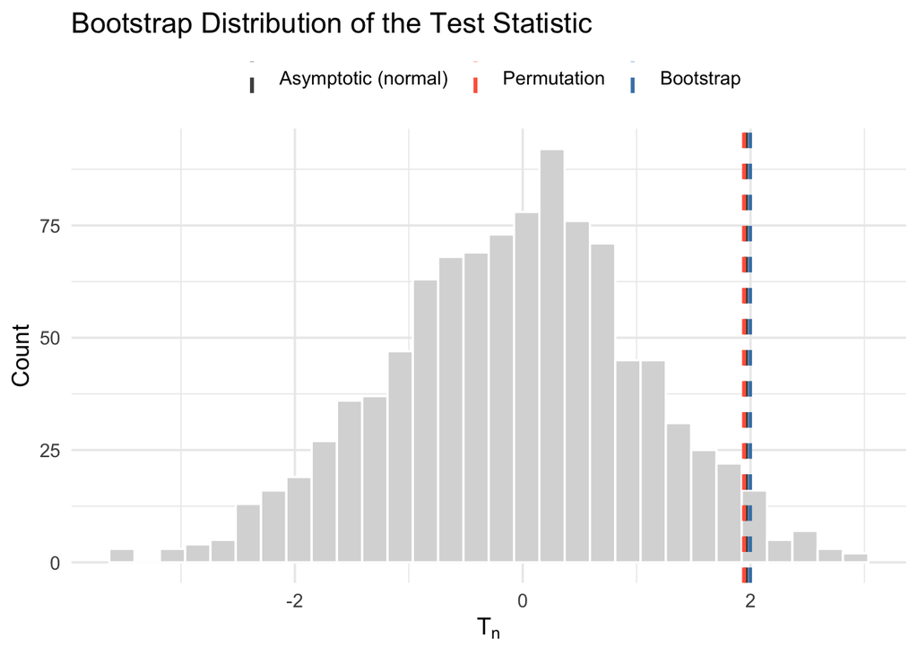

Figure 2: Bootstrap distribution of $T_n$, with the asymptotic, permutation, and bootstrap critical values.

```r
cv_boot <- data.frame(
  value     = c(qnorm(1 - alpha / 2), cn_alpha, cn_boot_alpha),
  Reference = factor(c("Asymptotic (normal)", "Permutation", "Bootstrap"),
                     levels = c("Asymptotic (normal)", "Permutation", "Bootstrap"))
)

ggplot(data.frame(tn_star = tn_star), aes(x = tn_star)) +
  geom_histogram(bins = 30, fill = "grey85", color = "white") +
  geom_vline(data = cv_boot, aes(xintercept = value, color = Reference),
             linetype = "dashed", linewidth = 1) +
  scale_color_manual(values = c("Asymptotic (normal)" = "grey30",
                                "Permutation"         = col_control,
                                "Bootstrap"           = col_treatment),
                     name = NULL) +
  theme_minimal(base_size = 13) +
  theme(legend.position = "top") +
  labs(title = "Bootstrap Distribution of the Test Statistic",
       x = expression(T[n]), y = "Count")
```

## 7.1 Confidence Intervals from the Bootstrap

The equivalence between tests and intervals carries over to the bootstrap: we only replace the normal quantile $z_{1-\alpha/2}$ by a quantile of the bootstrap law of $T_n^\star$. Write $J_n(\cdot,\hat P_n)$ for that law and $J_n^{-1}(\tau,\hat P_n) = \inf\{t : J_n(t,\hat P_n) \ge \tau\}$ for its quantiles; the upper quantile $J_n^{-1}(1-\alpha/2,\hat P_n)$ is precisely the critical value `cn_boot_alpha` computed above.

The **percentile bootstrap interval** takes the infeasible interval $\{\theta : J_n^{-1}(\alpha/2,P) \le T_n \le J_n^{-1}(1-\alpha/2,P)\}$ and replaces the unknown $P$ by $\hat P_n$. For the studentized statistic $T_n^\star$ this delivers the **percentile-$t$** interval

$$\hat C_n^B(1-\alpha) = \Big[\,\hat\beta - J_n^{-1}(1-\tfrac{\alpha}{2},\hat P_n)\,\widehat{\mathrm{SE}}(\hat\beta),\;
\hat\beta - J_n^{-1}(\tfrac{\alpha}{2},\hat P_n)\,\widehat{\mathrm{SE}}(\hat\beta)\,\Big].$$

Note the **quantile reversal**: the *upper* bootstrap quantile enters the *lower* endpoint. Under bootstrap consistency, $\mathbb{P}[\text{ATE} \in \hat C_n^B(1-\alpha)] \to 1-\alpha$, and — exactly as with the asymptotic interval — we reject $H_0:\text{ATE}=0$ whenever $0 \notin \hat C_n^B(1-\alpha)$.

**Studentized (percentile-t) bootstrap CI for the ATE**

```r
q_lo <- quantile(tn_star, alpha / 2)       # J_n^{-1}(alpha/2,   Phat)
q_hi <- quantile(tn_star, 1 - alpha / 2)   # J_n^{-1}(1-alpha/2, Phat)

boot_ci <- c(lower = unname(mod1$coefficients[2] - q_hi * se_beta_hat),
             upper = unname(mod1$coefficients[2] - q_lo * se_beta_hat))

round(boot_ci, 2)
```

```
  lower   upper
 530.87 3272.30
```

**Studentized (percentile-t) bootstrap CI for the ATE**

```r
(boot_ci["lower"] > 0 | boot_ci["upper"] < 0)   # TRUE => reject H0: ATE = 0
```

```
lower
 TRUE
```

The interval excludes zero, agreeing with the asymptotic and permutation conclusions. The confidence bands drawn on the QTE figures below are the analogous bootstrap intervals, computed pointwise at each quantile $\tau$. The Efron ordering and the standard-error plug-in variants (Case I and Case II) are developed in the dedicated bootstrap confidence-interval chapter.

# 8 Quantile Treatment Effects

The ATE conceals distributional heterogeneity: a program can lift average earnings while leaving the bottom of the distribution untouched. The QTE fills this gap. Under random assignment the marginal CDFs $F_1, F_0$ are identified from the two experimental groups, so a first estimate is simply the difference of empirical quantiles.

**Empirical quantile differences**

```r
quantiles          <- seq(0.10, 0.90, by = 0.05)
control_quantiles  <- quantile(lalonde.exp$re78[lalonde.exp$treat == 0], probs = quantiles)
treatment_quantiles<- quantile(lalonde.exp$re78[lalonde.exp$treat == 1], probs = quantiles)

qte_sample <- treatment_quantiles - control_quantiles
round(qte_sample, 2)
```

```
    10%     15%     20%     25%     30%     35%     40%     45%     50%     55%
   0.00    0.00    0.00  485.23  943.05 1505.98 1169.54 1456.30 1093.52 1187.88
    60%     65%     70%     75%     80%     85%     90%
1452.29 2121.32 1802.52 2354.58 2273.05 2186.23 3197.78
```

The `qte` package performs this calculations, and supplies standard errors, by default via the asymptotic approximation, and also via the bootstrap (we need only specify the number of Monte Carlo draws; in this case, 1000 bootstrap samples). The function `ci.qtet` targets the quantile treatment effect on the treated (QTT), which coincides with the QTE under random assignment.

**QTE with asymptotic and bootstrap standard errors**

```r
# Asymptotic standard errors (default)
qte_data <- ci.qtet(re78 ~ treat, data = lalonde.exp,
                    probs = seq(0.05, 0.95, 0.05))
summary(qte_data)

# Bootstrap standard errors
qte_data_boot <- ci.qtet(re78 ~ treat, data = lalonde.exp,
                        probs = seq(0.05, 0.95, 0.05),
                        se = TRUE, iters = n_boot)
summary(qte_data_boot)
```

**Visualise the QTE**

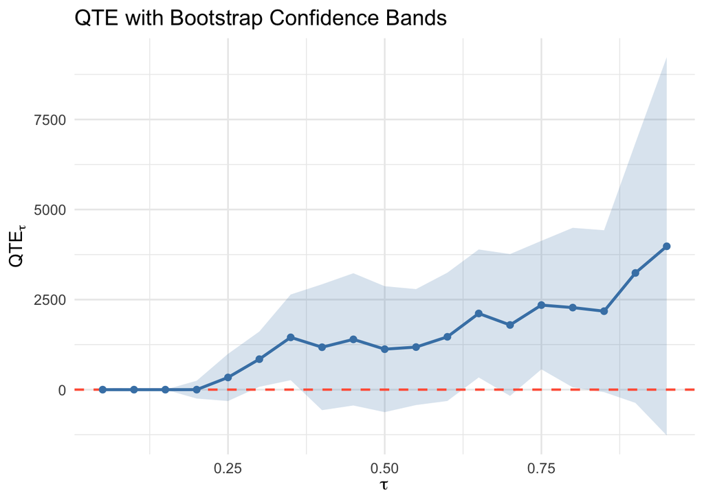

Figure 3: Estimated QTE across quantiles with bootstrap confidence bands.

```r
plot_qte_course(qte_data_boot, "QTE with Bootstrap Confidence Bands")
# Package default (fixed colours), as a fallback: ggqte(qte_data_boot)
```

## 8.1 Interpreting the QTE

How we read these numbers depends on an assumption about how individuals are *ranked* in the two potential-outcome distributions.

**NoteCase I — Rank invariance**

Under **rank invariance**, an individual occupies the same rank in $F_0$ and $F_1$: the person at the $\tau$-quantile of the control distribution is the same person who would be at the $\tau$-quantile of the treated distribution. Then $\text{QTE}_\tau$ *is* the treatment effect for that individual. For example, a QTE of $0$ at $\tau = 0.2$, and of about $1{,}124$ at $\tau = 0.5$, and of about $2{,}278$ at $\tau = 0.8$ would say the program had no effect for low earners, a moderate effect at the median, and a larger effect for higher earners. Under rank invariance, each statement is attached to specific people.

**WarningCase II — Rank reversals**

Rank invariance is strong and usually unrealistic. If the NSW program induces **rank reversals** — reshuffling who ends up where in the earnings distribution — then the difference of medians (or of any pair of quantiles) no longer identifies the effect *for a given person*. Knowing the median gap tells us nothing about the treatment effect of the individual who would have been at the median absent treatment. In this (more realistic) case the QTE is interpreted purely as a **distributional statement**: it measures the shift in the quantiles of the earnings distribution caused by the program, not an individual-level effect.

## 8.2 QTE with Covariates

When identification relies on covariates rather than pure randomization, the QTE requires a **conditional independence** assumption. The `qte` package accommodates covariates through the `xformla` argument; we again report both asymptotic and bootstrap inference, using two pre-determined covariates.

**Conditional QTE with covariates**

```r
# Asymptotic
qte_covar <- ci.qtet(re78 ~ treat, xformla = ~ age + education,
                    data = lalonde.exp, probs = seq(0.05, 0.95, 0.05))
summary(qte_covar)

# Bootstrap
qte_covar_boot <- ci.qtet(re78 ~ treat, xformla = ~ age + education,
                         data = lalonde.exp, probs = seq(0.05, 0.95, 0.05),
                         se = TRUE, iters = n_boot)
summary(qte_covar_boot)
```

**Visualise the conditional QTE**

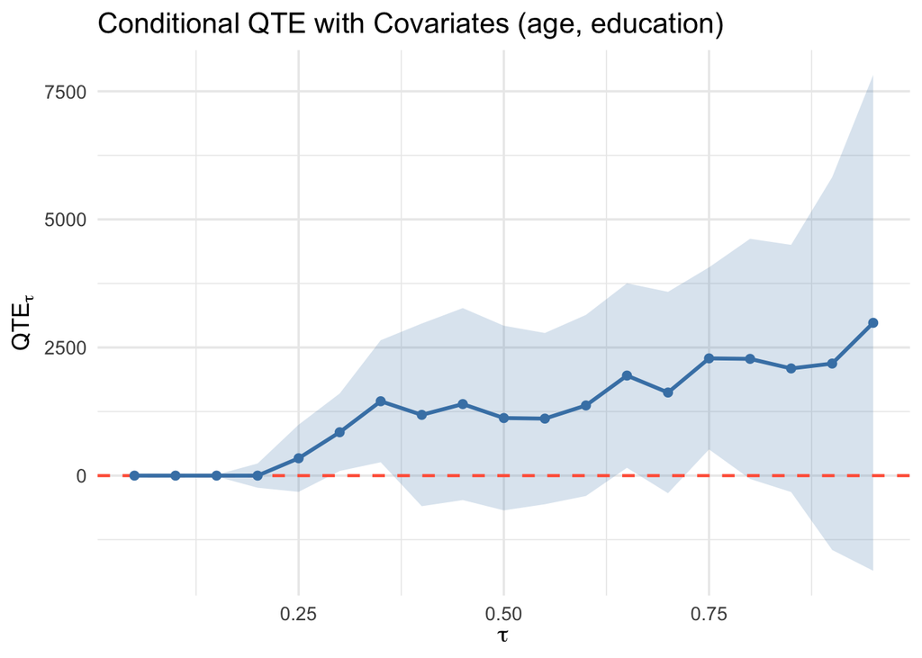

Figure 4: Conditional QTE with covariates and bootstrap confidence bands.

```r
plot_qte_course(qte_covar_boot, "Conditional QTE with Covariates (age, education)")
# Package default (fixed colours), as a fallback: ggqte(qte_covar_boot)
```

# References

Chung, EunYi, and Joseph P. Romano. 2013. “Exact and Asymptotically Robust Permutation Tests.” *The Annals of Statistics* 41 (2): 484–507.

LaLonde, Robert J. 1986. “Evaluating the Econometric Evaluations of Training Programs with Experimental Data.” *The American Economic Review* 76 (4): 604–20.